# Análise Exploratória de Dados da Educação Superior em R

# 1. Introdução

Neste notebook do R iremos analisar microdados educaionais extraidos do [Senso Educacional 2024] (https://www.gov.br/inep/pt-br/acesso-a-informacao/dados-abertos/microdados/censo-da-educacao-superior)

# 2. Lendo os dados

Os comandos abaixo fará a leitura dos seguintes dados:

```r
library(readxl)
# DICIONAÁRIO DE DADOS
disc_dados <- read_excel("/users/waldex/Documents/Github/Projeto_Ferramentas_Computacionais/microdados_censo_da_educacao_superior_2024/dicionário_dados_educação_superior.xlsx")
#caminho_correto <- file.choose()
#print(caminho_correto)
```

```r
#CURSOS
cadastro_cursos<-read.csv("/Users/waldex/Documents/GitHub/Projeto_Ferramentas_Computacionais/microdados_censo_da_educacao_superior_2024/MICRODADOS_CADASTRO_CURSOS_2024.CSV", sep=';', encoding='latin1')
```

```r
#CURSOS
microdados_ies<-read.csv("/Users/waldex/Documents/GitHub/Projeto_Ferramentas_Computacionais/microdados_censo_da_educacao_superior_2024/MICRODADOS_ED_SUP_IES_2024.CSV", sep=";", encoding = "latin1", header = TRUE)
```

```r
POP_UF <- read_excel("/users/waldex/Documents/Github/Projeto_Ferramentas_Computacionais/dados_populacionais/POP_UF.xls")

head(POP_UF)
```

| CO_REGIAO_IES | REGIAO | POPULAÇÃO |
| --- | --- | --- |
| 1 | Norte | 17834762 |
| 2 | Nordeste | 55389382 |
| 3 | Sudeste | 87348223 |
| 4 | Sul | 30685598 |
| 5 | Centro-Oeste | 16492326 |

##2.1. Formando uma base de dados com as Instituções de Ensino Superior para filtrar informações de interesse

```r
library(dplyr)

dados_ies <- data.frame(
  "REGIAO" = microdados_ies$NO_REGIAO_IES,
  "ESTADO" = microdados_ies$NO_UF_IES,
  "UF" = microdados_ies$SG_UF_IES,
  "MUNICIPIO" = microdados_ies$NO_MUNICIPIO_IES,

  # Mapeamento: IN_CAPITAL_IES (usando ifelse)
  "CAPITAL" = ifelse(microdados_ies$IN_CAPITAL_IES == 1, "Sim", "Não"),

  # Mapeamento: TP_REDE (usando ifelse)
  "REDE" = ifelse(microdados_ies$TP_REDE == 1, "Pública", "Privada"),

  # Mapeamento: TP_ORGANIZACAO_ACADEMICA (usando case_when para mapeamento de múltiplos valores)
  "NOME_CURSO" = case_when(
    microdados_ies$TP_ORGANIZACAO_ACADEMICA == 1 ~ "Universidade",
    microdados_ies$TP_ORGANIZACAO_ACADEMICA == 2 ~ "Centro Universitário",
    microdados_ies$TP_ORGANIZACAO_ACADEMICA == 3 ~ "Faculdade",
    microdados_ies$TP_ORGANIZACAO_ACADEMICA == 4 ~ "Instituto Federal",
    microdados_ies$TP_ORGANIZACAO_ACADEMICA == 5 ~ "Centro Federal de Ed. Tecnológica",
    TRUE ~ NA_character_ # Para qualquer outro valor, atribui NA (ou outro valor padrão)
  ),

  # Mapeamento: TP_CATEGORIA_ADMINISTRATIVA (Equivalente à função lambda)
  "ORG. ADM" = case_when(
    microdados_ies$TP_CATEGORIA_ADMINISTRATIVA >= 4 ~ "Privada",
    microdados_ies$TP_CATEGORIA_ADMINISTRATIVA == 1 ~ "Federal",
    microdados_ies$TP_CATEGORIA_ADMINISTRATIVA == 2 ~ "Estadual",
    microdados_ies$TP_CATEGORIA_ADMINISTRATIVA == 3 ~ "Municipal",
    TRUE ~ NA_character_ # Caso contrário (ou valor não mapeado)
  ),

  "NOME_IES" = microdados_ies$NO_IES,
  "CO_IES" = microdados_ies$CO_IES,
  "SIGLA_IES" = microdados_ies$SG_IES,

  # Colunas Quantitativas Simples
  "QT_TEC_TOTAL" = microdados_ies$QT_TEC_TOTAL,
  "QT_TEC_FUND_INCOMP_FEM" = microdados_ies$QT_TEC_FUNDAMENTAL_INCOMP_FEM,
  "QT_TEC_FUND_INCOMP_MASC" = microdados_ies$QT_TEC_FUNDAMENTAL_INCOMP_MASC,
  "QT_TEC_FUND_COMP_FEM" = microdados_ies$QT_TEC_FUNDAMENTAL_COMP_FEM,
  "QT_TEC_FUND_COMP_MASC" = microdados_ies$QT_TEC_FUNDAMENTAL_COMP_MASC,
  "QT_TEC_MEDIO_FEM" = microdados_ies$QT_TEC_MEDIO_FEM,
  "QT_TEC_MEDIO_MASC" = microdados_ies$QT_TEC_MEDIO_MASC,
  "QT_TEC_SUPERIOR_FEM" = microdados_ies$QT_TEC_SUPERIOR_FEM,
  "QT_TEC_SUPERIOR_MASC" = microdados_ies$QT_TEC_SUPERIOR_MASC,
  "QT_TEC_ESPECIALIZACAO_FEM" = microdados_ies$QT_TEC_ESPECIALIZACAO_FEM,
  "QT_TEC_ESPECIALIZACAO_MASC" = microdados_ies$QT_TEC_ESPECIALIZACAO_MASC,
  "QT_TEC_MESTRADO_FEM" = microdados_ies$QT_TEC_MESTRADO_FEM,
  "QT_TEC_MESTRADO_MASC" = microdados_ies$QT_TEC_MESTRADO_MASC,
  "QT_TEC_DOUTORADO_FEM" = microdados_ies$QT_TEC_DOUTORADO_FEM,
  "QT_TEC_DOUTORADO_MASC" = microdados_ies$QT_TEC_DOUTORADO_MASC,
  "QT_DOC_TOTAL" = microdados_ies$QT_DOC_TOTAL,
  "QT_DOC_EXE" = microdados_ies$QT_DOC_EXE,
  "QT_DOC_EX_FEM" = microdados_ies$QT_DOC_EX_FEMI, # Notei QT_DOC_EX_FEMI no seu código Python
  "QT_DOC_EX_MASC" = microdados_ies$QT_DOC_EX_MASC,
  "QT_DOC_EX_SEM_GRAD" = microdados_ies$QT_DOC_EX_SEM_GRAD,
  "QT_DOC_EX_GRAD" = microdados_ies$QT_DOC_EX_GRAD,
  "QT_DOC_EX_ESPEC" = microdados_ies$QT_DOC_EX_ESP, # Notei QT_DOC_EX_ESP no seu código Python
  "QT_DOC_EX_MESTRE" = microdados_ies$QT_DOC_EX_MEST,
  "QT_DOC_EX_DOUTOR" = microdados_ies$QT_DOC_EX_DOUT,
  "QT_DOC_EX_0_29" = microdados_ies$QT_DOC_EX_0_29,
  "QT_DOC_EX_30_34" = microdados_ies$QT_DOC_EX_30_34,
  "QT_DOC_EX_35_39" = microdados_ies$QT_DOC_EX_35_39,
  "QT_DOC_EX_40_44" = microdados_ies$QT_DOC_EX_40_44,
  "QT_DOC_EX_45_49" = microdados_ies$QT_DOC_EX_45_49,
  "QT_DOC_EX_50_54" = microdados_ies$QT_DOC_EX_50_54,
  "QT_DOC_EX_55_59" = microdados_ies$QT_DOC_EX_55_59,
  "QT_DOC_EX_60_MAIS" = microdados_ies$QT_DOC_EX_60_MAIS,
  "QT_DOC_EX_BRANCA" = microdados_ies$QT_DOC_EX_BRANCA,
  "QT_DOC_EX_PRETA" = microdados_ies$QT_DOC_EX_PRETA,
  "QT_DOC_EX_PARDA" = microdados_ies$QT_DOC_EX_PARDA,
  "QT_DOC_EX_AMARELA" = microdados_ies$QT_DOC_EX_AMARELA,
  "QT_DOC_EX_INDIGENA" = microdados_ies$QT_DOC_EX_INDIGENA,
  "QT_DOC_EX_COR_ND" = microdados_ies$QT_DOC_EX_COR_ND
)
```

```r
#dim(microdados_ies)
#dim(dados_ies)
head(dados_ies)
```

|  | REGIAO | ESTADO | UF | MUNICIPIO | CAPITAL | REDE | NOME_CURSO | ORG..ADM | NOME_IES | CO_IES | SIGLA_IES | QT_TEC_TOTAL | QT_TEC_FUND_INCOMP_FEM | QT_TEC_FUND_INCOMP_MASC | QT_TEC_FUND_COMP_FEM | QT_TEC_FUND_COMP_MASC | QT_TEC_MEDIO_FEM | QT_TEC_MEDIO_MASC | QT_TEC_SUPERIOR_FEM | QT_TEC_SUPERIOR_MASC | QT_TEC_ESPECIALIZACAO_FEM | QT_TEC_ESPECIALIZACAO_MASC | QT_TEC_MESTRADO_FEM | QT_TEC_MESTRADO_MASC | QT_TEC_DOUTORADO_FEM | QT_TEC_DOUTORADO_MASC | QT_DOC_TOTAL | QT_DOC_EXE | QT_DOC_EX_FEM | … |
| --- | --- | --- | --- | --- | --- | --- | --- | --- | --- | --- | --- | --- | --- | --- | --- | --- | --- | --- | --- | --- | --- | --- | --- | --- | --- | --- | --- | --- | --- | --- |
| 1 | Centro-Oeste | Mato Grosso | MT | Cuiabá | Sim | Pública | Universidade | Federal | UNIVERSIDADE FEDERAL DE MATO GROSSO | 1 | UFMT | 1297 | 8 | 1 | 2 | 9 | 21 | 57 | 66 | 84 | 338 | 329 | 179 | 116 | 56 | 31 | 1791 | 1791 | 881 | … |
| 2 | Centro-Oeste | Distrito Federal | DF | Brasília | Sim | Pública | Universidade | Federal | UNIVERSIDADE DE BRASÍLIA | 2 | UNB | 3051 | 1 | 0 | 2 | 20 | 96 | 113 | 207 | 225 | 777 | 709 | 416 | 274 | 130 | 81 | 2799 | 2799 | 1288 | … |
| 3 | Nordeste | Sergipe | SE | São Cristóvão | Não | Pública | Universidade | Federal | UNIVERSIDADE FEDERAL DE SERGIPE | 3 | UFS | 1759 | 0 | 21 | 7 | 12 | 141 | 114 | 309 | 242 | 268 | 181 | 221 | 135 | 66 | 42 | 1809 | 1809 | 871 | … |
| 4 | Norte | Amazonas | AM | Manaus | Sim | Pública | Universidade | Federal | UNIVERSIDADE FEDERAL DO AMAZONAS | 4 | UFAM | 1358 | 4 | 1 | 2 | 8 | 44 | 53 | 99 | 144 | 358 | 265 | 180 | 128 | 38 | 34 | 1818 | 1818 | 828 | … |
| 5 | Nordeste | Piauí | PI | Teresina | Sim | Pública | Universidade | Federal | UNIVERSIDADE FEDERAL DO PIAUÍ | 5 | UFPI | 1235 | 2 | 10 | 1 | 18 | 122 | 151 | 70 | 84 | 241 | 207 | 143 | 103 | 46 | 37 | 1495 | 1495 | 724 | … |
| 6 | Sudeste | Minas Gerais | MG | Ouro Preto | Não | Pública | Universidade | Federal | UNIVERSIDADE FEDERAL DE OURO PRETO | 6 | UFOP | 729 | 4 | 24 | 2 | 26 | 18 | 55 | 37 | 66 | 91 | 119 | 113 | 99 | 47 | 28 | 885 | 885 | 359 | … |

## 2.2. Formando uma base de dados com informações dos cursos para filtrar informações de interesse

```r
library(dplyr)
dados_cursos <- cadastro_cursos %>%
  transmute(
    # Mapeamentos simples usando case_when (melhor que if/else aninhado)
    REDE = case_when(
      TP_REDE == 1 ~ "Pública",
      TP_REDE == 2 ~ "Privada",
      TRUE ~ NA_character_ # Default para valores ausentes/não mapeados
    ),

    # Mapeamento para NOME_CURSO INST.
    `NOME_CURSO INST.` = case_when(
      TP_ORGANIZACAO_ACADEMICA == 1 ~ "Universidade",
      TP_ORGANIZACAO_ACADEMICA == 2 ~ "Centro Universitário",
      TP_ORGANIZACAO_ACADEMICA == 3 ~ "Faculdade",
      TP_ORGANIZACAO_ACADEMICA == 4 ~ "Instituto Federal",
      TP_ORGANIZACAO_ACADEMICA == 5 ~ "Centro Federal de Ed. Tecnológica",
      TRUE ~ NA_character_
    ),

    # Lógica condicional complexa para ORG. ADM
    `ORG. ADM` = case_when(
      TP_CATEGORIA_ADMINISTRATIVA >= 4 ~ "Privada",
      TP_CATEGORIA_ADMINISTRATIVA == 1 ~ "Federal",
      TP_CATEGORIA_ADMINISTRATIVA == 2 ~ "Estadual",
      TP_CATEGORIA_ADMINISTRATIVA == 3 ~ "Municipal",
      TRUE ~ NA_character_
    ),

    # Mapeamento para TIPO
    TIPO = case_when(
      TP_GRAU_ACADEMICO == 1 ~ "Bacharelado",
      TP_GRAU_ACADEMICO == 2 ~ "Licenciatura",
      TP_GRAU_ACADEMICO == 3 ~ "Tecnólogo",
      TP_GRAU_ACADEMICO == 4 ~ "Bacharelado e Licenciatura",
      # A lógica original do Python mapeia qualquer outro valor para "Não se aplica"
      TRUE ~ "Não se aplica"
    ),

    # Mapeamento para GRAT
    GRAT = case_when(
      IN_GRATUITO == 0 ~ "Particular",
      IN_GRATUITO == 1 ~ "Gratuíto",
      TRUE ~ NA_character_
    ),

    # Mapeamento para MODALIDADE
    MODALIDADE = case_when(
      TP_MODALIDADE_ENSINO == 1 ~ "Presencial",
      TP_MODALIDADE_ENSINO == 2 ~ "à distância",
      TRUE ~ NA_character_
    ),

    # Colunas que são apenas cópias diretas
    CO_IES = CO_IES,
    CO_CURSO = CO_CURSO,
    NOME_CURSO = NO_CURSO,
    QT_VAGAS = QT_VG_TOTAL,
    QT_INSC = QT_INSCRITO_TOTAL,
    QT_ING = QT_ING,
    QT_ING_FEM = QT_ING_FEM,
    QT_ING_MASC = QT_ING_MASC,
    QT_ING_ENEM = QT_ING_ENEM,
    `QT_ING_0-17` = `QT_ING_0_17`, # Aspas simples são necessárias no Python; no R, use backticks se o nome não for válido
    `QT_ING_18-24` = `QT_ING_18_24`,
    `QT_ING_25-29` = `QT_ING_25_29`,
    `QT_ING_30-34` = `QT_ING_30_34`,
    `QT_ING_35-39` = `QT_ING_35_39`,
    `QT_ING_40-49` = `QT_ING_40_49`,
    `QT_ING_50-59` = `QT_ING_50_59`,
    `QT_ING_60+` = `QT_ING_60_MAIS`,
    QT_ING_BRANCA = QT_ING_BRANCA,
    QT_ING_PRETA = QT_ING_PRETA,
    QT_ING_PARDA = QT_ING_PARDA,
    QT_ING_AMARELA = QT_ING_AMARELA,
    QT_ING_INDIGENA = QT_ING_INDIGENA,
    QT_ING_COR_ND = QT_ING_CORND,
    QT_MAT = QT_MAT,
    QT_MAT_FEM = QT_MAT_FEM,
    QT_MAT_MASC = QT_MAT_MASC,
    QT_CONC = QT_CONC,
    QT_CONC_FEM = QT_CONC_FEM,
    QT_CONC_MASC = QT_CONC_MASC
  )
```

```r
head(dados_cursos)
```

|  | REDE | NOME_CURSO INST. | ORG. ADM | TIPO | GRAT | MODALIDADE | CO_IES | CO_CURSO | NOME_CURSO | QT_VAGAS | QT_INSC | QT_ING | QT_ING_FEM | QT_ING_MASC | QT_ING_ENEM | QT_ING_0-17 | QT_ING_18-24 | QT_ING_25-29 | QT_ING_30-34 | QT_ING_35-39 | QT_ING_40-49 | QT_ING_50-59 | QT_ING_60+ | QT_ING_BRANCA | QT_ING_PRETA | QT_ING_PARDA | QT_ING_AMARELA | QT_ING_INDIGENA | QT_ING_COR_ND | … |
| --- | --- | --- | --- | --- | --- | --- | --- | --- | --- | --- | --- | --- | --- | --- | --- | --- | --- | --- | --- | --- | --- | --- | --- | --- | --- | --- | --- | --- | --- | --- |
| 1 | Privada | Universidade | Privada | Não se aplica | Particular | à distância | 417 | 5001662 | Abi - Educação Física | 0 | 0 | 12 | 6 | 6 | 1 | 0 | 1 | 0 | 6 | 1 | 4 | 0 | 0 | 8 | 1 | 1 | 1 | 0 | 1 | … |
| 2 | Privada | Universidade | Privada | Não se aplica | Particular | à distância | 953 | 50017193 | Abi - Educação Física | 3702 | 817 | 0 | 0 | 0 | 0 | 0 | 0 | 0 | 0 | 0 | 0 | 0 | 0 | 0 | 0 | 0 | 0 | 0 | 0 | … |
| 3 | Privada | Universidade | Privada | Não se aplica | Particular | à distância | 275 | 50017183 | Abi - Educação Física | 809 | 216 | 0 | 0 | 0 | 0 | 0 | 0 | 0 | 0 | 0 | 0 | 0 | 0 | 0 | 0 | 0 | 0 | 0 | 0 | … |
| 4 | Privada | Universidade | Privada | Não se aplica | Particular | à distância | 423 | 5001615 | Abi - Educação Física | 231 | 126 | 0 | 0 | 0 | 0 | 0 | 0 | 0 | 0 | 0 | 0 | 0 | 0 | 0 | 0 | 0 | 0 | 0 | 0 | … |
| 5 | Privada | Universidade | Privada | Não se aplica | Particular | à distância | 482 | 50017101 | Abi - Educação Física | 0 | 0 | 28 | 8 | 20 | 0 | 0 | 10 | 4 | 5 | 3 | 3 | 2 | 1 | 16 | 3 | 2 | 0 | 0 | 7 | … |
| 6 | Privada | Universidade | Privada | Não se aplica | Particular | à distância | 10 | 5001649 | Abi - Educação Física | 0 | 0 | 0 | 0 | 0 | 0 | 0 | 0 | 0 | 0 | 0 | 0 | 0 | 0 | 0 | 0 | 0 | 0 | 0 | 0 | … |

# 3. Analisando o panoram Geral das Instituições de ensino Supeior

```r
tabela_frequencia <- dados_ies %>%
  # 1. Agrupando os dados pela coluna 'REGIAO'
  group_by(REGIAO) %>%
  # 2. Contando o número de ocorrências de cada região (valores absolutos)
  summarise(
    Valores_absolutos = n(),
    .groups = 'drop' # Remove o agrupamento após a sumarização
  ) %>%
  # 3. Calculando o total de instituições (para normalizar)
  mutate(
    Total_Geral = sum(Valores_absolutos),
    # 4. Calculando o percentual e arredondando para 2 casas decimais
    `Percentual (%)` = round((Valores_absolutos / Total_Geral) * 100, 2)
  ) %>%
  # 5. Removendo a coluna auxiliar 'Total_Geral'
  select(-Total_Geral)
```

```r
# Exibindo o total de instituições
total <- sum(tabela_frequencia$Valores_absolutos)
cat(paste("Total de instituições:", total, "\n\n"))
```

```
Total de instituições: 2561
```

Temos um total de 2561 Instituições de Ensino Superior (IES) no Brasil, segundo os dados disponibilizados. Destas a grande maioria, cerca de 42, 01% estão localizadas na região Sudeste. a região Norte é o que tem menos insitutições superiores, apenas 7,65%. Observe que se somarmos o quantitativo das regiões Norte, Sul e Centro-Oeste não atingimos o total de instituições da região sudeste. O que mostra a grande discrepância do número de instituições de nível superior nas regiões do Brasil, conforme evidencia o gráfico seguinte.

```r
library(knitr)
# Exibindo a tabela  com os valores absoltuos e percentuais
kable(
  tabela_frequencia,
  caption = "Tabela 1: Valores absolutos e percentuais de IES por região",
  format = "pipe" # ou "html", "latex", dependendo do seu output
)
```

Tabela 1: Valores absolutos e percentuais de IES por região

| REGIAO | Valores_absolutos | Percentual (%) |
| --- | --- | --- |
| Centro-Oeste | 296 | 11.56 |
| Nordeste | 604 | 23.58 |
| Norte | 196 | 7.65 |
| Sudeste | 1076 | 42.01 |
| Sul | 389 | 15.19 |

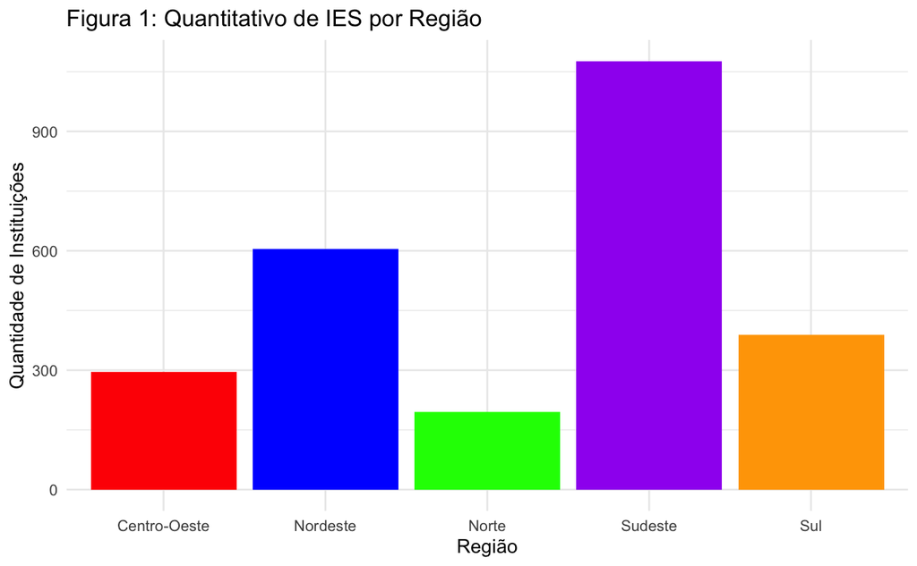

```r
library(ggplot2)

# Definindo o vetor de cores (similar à paleta do Python)
cores <- c('red', 'blue', 'green', 'purple', 'orange')

# Criando o gráfico de barras de contagem
ggplot(dados_ies, aes(x = REGIAO)) + # Define os dados e a variável X
  geom_bar(fill = cores) + # Cria o gráfico de barras e aplica as cores
  labs(
    title = 'Figura 1: Quantitativo de IES por Região',
    x = 'Região',
    y = 'Quantidade de Instituições'
  ) +
  theme_minimal()
```

Sudeste e Nordeste são as duas regiões do Brasil mais populosas de acordo com IBGE (IBGE, 2022), o que nos faz pensar, obviamente, que por conta disso tem maior quantidade de IES, tendo em vista a maior demanda populacional. Isso nos leva a indagar se em termos percentuais há uma discrepância ou similaridade na quantidade de instituições superiores em nosso território, conforme as necessidades de cada região em número de habitantes. Para responder a tal indagação iremos ver a relação entre quantidade de IES e a população.

Utilizamos a projeção do senso feita em 2022 para o ano de 2023 para alinhar com os dados das IES. Fizemos a razão quantidade de instituições pelo número de habitantes de cada região e, como o valor é muito pequeno, colocamos na relação para cada 100 mil habitantes, conforme exibe a Tabela 2.

##3.1. Quantidade de instituições x populacão

```r
#Realizar a junção (merge) e manipulação
library(dplyr)
pop_ies <- tabela_frequencia %>%
  left_join(POP_UF, by = "REGIAO") %>%
  select(-CO_REGIAO_IES) %>%
  rename(
    `Val._abs._IES` = Valores_absolutos,
    `Percentual_ies (%)` = `Percentual (%)`
  )
```

```r
#Cálculo de densidade por região
pop_ies <- tabela_frequencia %>%
  left_join(POP_UF, by = "REGIAO") %>%
  select(-CO_REGIAO_IES) %>%
  rename(
    `Val._abs._IES` = Valores_absolutos,
    `Percentual_ies (%)` = `Percentual (%)`
  ) %>%
  mutate(
    # Calcula IES por 100.000 habitantes
    IES_por_100k = round((`Val._abs._IES` / POPULAÇÃO) * 100000, 2)
  )

pop_ies
```

| REGIAO | Val._abs._IES | Percentual_ies (%) | POPULAÇÃO | IES_por_100k |
| --- | --- | --- | --- | --- |
| Centro-Oeste | 296 | 11.56 | 16492326 | 1.79 |
| Nordeste | 604 | 23.58 | 55389382 | 1.09 |
| Norte | 196 | 7.65 | 17834762 | 1.10 |
| Sudeste | 1076 | 42.01 | 87348223 | 1.23 |
| Sul | 389 | 15.19 | 30685598 | 1.27 |

```r
library(knitr)
kable(
  pop_ies,
  caption = "Tabela 2: Quantidade de  IES por 100k habitantes",
  format = "pipe"
)
```

Tabela 2: Quantidade de IES por 100k habitantes

| REGIAO | Val._abs._IES | Percentual_ies (%) | POPULAÇÃO | IES_por_100k |
| --- | --- | --- | --- | --- |
| Centro-Oeste | 296 | 11.56 | 16492326 | 1.79 |
| Nordeste | 604 | 23.58 | 55389382 | 1.09 |
| Norte | 196 | 7.65 | 17834762 | 1.10 |
| Sudeste | 1076 | 42.01 | 87348223 | 1.23 |
| Sul | 389 | 15.19 | 30685598 | 1.27 |

Observamos que a região Centro-Oeste, apesar de ser a segunda menor em número de IES, em termos proporcionais a população, é a que apresentar maior número proporcional de IES. O que vai de encontro aos valores absolutos. A região Sudeste que tem o maior percentual de IES,em termos proporcionais tem menos IES do que a própria região Sul. Neste sentido, a distribuição de IES no território nacional não privelegia Regiões mais populosas, conseguindo equilibrar a demandanda regional.

### IES por Unidades Federativas (UFs)

```r
library(dplyr)

tabela_est <- dados_ies %>%
  # Agrupa os dados pela coluna 'UF'
  group_by(UF) %>%
  # Conta as ocorrências (Valores absolutos)
  summarise(
    `Val._absolutos` = n(),
    .groups = 'drop' # Remove o agrupamento
  ) %>%
  # Calcula o total geral para normalização
  mutate(
    Total_Geral = sum(`Val._absolutos`),
    # Calcula o percentual e arredonda para 2 casas decimais
    Percentual = round((`Val._absolutos` / Total_Geral) * 100, 2)
  ) %>%
  # Remove a coluna auxiliar e seleciona a ordem final
  select(-Total_Geral)

# Exibe a tabela
tabela_est
```

| UF | Val._absolutos | Percentual |
| --- | --- | --- |
| AC | 10 | 0.39 |
| AL | 30 | 1.17 |
| AM | 32 | 1.25 |
| AP | 15 | 0.59 |
| BA | 145 | 5.66 |
| CE | 102 | 3.98 |
| DF | 63 | 2.46 |
| ES | 67 | 2.62 |
| GO | 128 | 5.00 |
| MA | 66 | 2.58 |

[output cut: 17 more lines]

```r
library(dplyr)

# Ordena a tabela pela coluna 'Val._absolutos' de forma crescente
tabela_est_ord <- tabela_est %>%
  arrange(`Val._absolutos`)

tabela_est_ord
```

[output not shown]

Quando analisamos o quantitativo de instituições por estado, temos um panorama não muito diferente (Figura 2). No entanto, com exceção de São Paulo e Minas Gerais, que são os estados mais populosos do Brasil (IBGE, 2022) e que possui o maior número de IES, o estado do Rio de Janeiro, por exemplo, que é o terceiro mais populoso, tem menos IES do que Paraná e Bahia. Na outra ponta, os estados menos populosos também segue com o menor número de IES, como Roraima, Amapá e Acre.

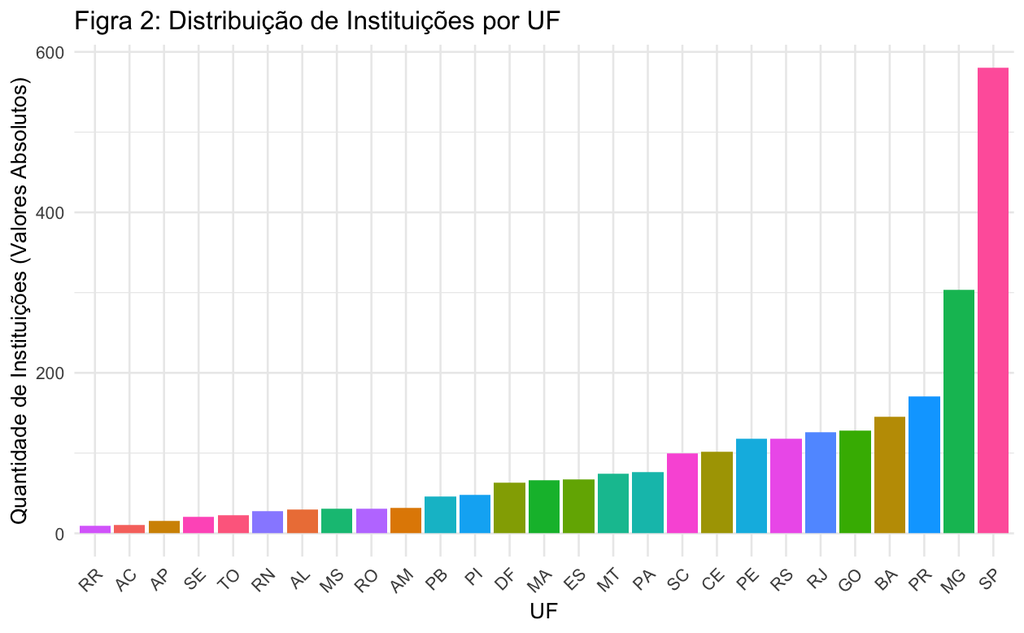

```r
# Certifique-se de que os pacotes necessários estão carregados
library(ggplot2)
library(dplyr)
library(forcats) # Pacote para manipular fatores, essencial para ordenar o eixo



ggplot(tabela_est, aes(x = fct_reorder(UF, `Val._absolutos`), y = `Val._absolutos`)) +
  geom_bar(stat = "identity", aes(fill = UF)) + # O ggplot2 gera 27 cores
  labs(
    title = 'Figra 2: Distribuição de Instituições por UF',
    x = 'UF',
    y = 'Quantidade de Instituições (Valores Absolutos)'
  ) +
  theme_minimal() +
  theme(
    axis.text.x = element_text(angle = 45, hjust = 1),
    legend.position = "none"
  )
```

Para deixar mais ilustrativo a diferença grande do número de IES entre os estados, plotamos o “gráfico de Pareto” da Figura 3. O gráfico mostra a distribuição de instituições por UF, com os valores absolutos em ordem decrescente. A barra azul representa a quantidade de instituições em cada UF. A linha vermelha acompanha os valores absolutos, mostrando a tendência da distribuição.

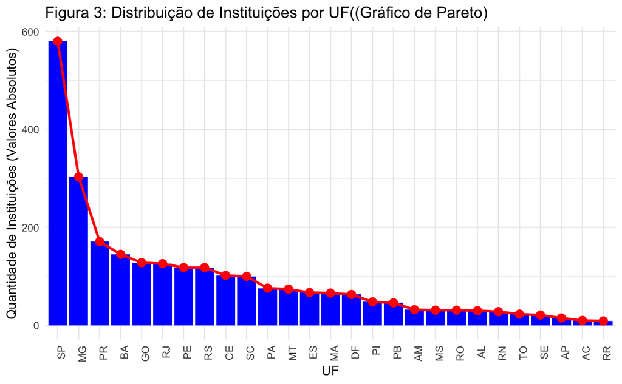

```r
library(dplyr)
library(ggplot2)
library(forcats) # Necessário para fct_reorder

# 1. Ordenar o data frame por 'Val._absolutos' de forma decrescente
tabela_est_ord <- tabela_est %>%
  arrange(desc(`Val._absolutos`))

# 2. Criar o gráfico
ggplot(tabela_est_ord, aes(x = fct_reorder(UF, `Val._absolutos`, .desc = TRUE))) +

  # Gráfico de barras (Valores Absolutos)
  geom_bar(aes(y = `Val._absolutos`), stat = "identity", fill = 'blue') +

  # Gráfico de linha (Valores Absolutos)
  geom_line(aes(y = `Val._absolutos`, group = 1), color = 'red', linewidth = 1) +
  geom_point(aes(y = `Val._absolutos`), color = 'red', size = 3) +

  labs(
    title = 'Figura 3: Distribuição de Instituições por UF((Gráfico de Pareto)',
    x = 'UF',
    y = 'Quantidade de Instituições (Valores Absolutos)'
  ) +
  theme_minimal() +
  theme(
    axis.text.x = element_text(angle = 90, hjust = 1) # Rotação do eixo X
  )
```

Os primeiros UFs têm uma grande quantidade de instituições, indicando uma concentração de instituições nesses estados. Observe um declínio mais acentuado entre os três primeiros estados. Dai o declínio é mais gradual. Neste sentido, o gráfico de Pareto evidencia uma concentração das IES em poucos estados, como São Paulo e Minas Gerais. Os estados com maior número de IES estão no topo, enquanto os estados menos populosos, como Roraima e Amapá, possuem menor quantidade.

## 3.2. Instituições Públicas x Instituições Privadas

Nesta seção iremos fazer um panorama entre Instituições públicas e privadas. Consoante a Tabela 3 o quantitativo de instituições privadas é muito superior ao quantitativo de instituições públicas (87,6% das IES no Brasil são privadas e 12,4% são públicas). Apesar da discrepância gigantesca entre o número de IES públicas e privadas em todo o país, se analisarmos por regição, há um equilíbrio na distribuição de IES privadas e, com exceção da região Sul e Centro-Oeste também há um certo equilíbrio na distribuição de IES públicas nas regiões.

```r
library(dplyr)
library(tidyr) # Necessário para pivot_wider, se quisermos reestruturar a tabela de forma robusta

# 1. Cria a contagem dos valores absolutos e o total por REGIÃO
regiao_REDE_inst <- dados_ies %>%
  group_by(REGIAO, REDE) %>%
  summarise(N = n(), .groups = 'drop') %>%

  # Transforma o formato longo (linhas) em formato largo (colunas)
  pivot_wider(names_from = REDE, values_from = N, values_fill = 0) %>%

  # 2. Adiciona a linha de 'Total' por região
  mutate(
    Total = Pública + Privada
  ) %>%

  # 3. Calcula os percentuais (substituindo o crosstab do Pandas)
  mutate(
    `%Pública` = round((Pública / Total) * 100, 1),
    `%Privada` = round((Privada / Total) * 100, 1)
  )

# 4. Adiciona a linha de TOTAL GERAL (similar ao margins=True)
# Calcula os totais de cada coluna (Pública, Privada, Total)
total_geral <- regiao_REDE_inst %>%
  summarise(
    REGIAO = "Total",
    Pública = sum(Pública),
    Privada = sum(Privada),
    Total = sum(Total),
    `%Pública` = round((Pública / Total) * 100, 1),
    `%Privada` = round((Privada / Total) * 100, 1)
  )

# 5. Combina a tabela de regiões com a linha de Total Geral
regiao_REDE_inst <- bind_rows(regiao_REDE_inst, total_geral)

# 6. Renomeia a tabela final para o nome que você pretendia
regiao_NOME_CURSO_inst <- regiao_REDE_inst

regiao_NOME_CURSO_inst
```

| REGIAO | Privada | Pública | Total | %Pública | %Privada |
| --- | --- | --- | --- | --- | --- |
| Centro-Oeste | 269 | 27 | 296 | 9.1 | 90.9 |
| Nordeste | 538 | 66 | 604 | 10.9 | 89.1 |
| Norte | 172 | 24 | 196 | 12.2 | 87.8 |
| Sudeste | 910 | 166 | 1076 | 15.4 | 84.6 |
| Sul | 355 | 34 | 389 | 8.7 | 91.3 |
| Total | 2244 | 317 | 2561 | 12.4 | 87.6 |

```r
library(knitr)
kable(
  regiao_NOME_CURSO_inst,
  caption = "Tabela 3: Quantidade de  IES Pública X Privada por região",
  format = "pipe"
)
```

Tabela 3: Quantidade de IES Pública X Privada por região

| REGIAO | Privada | Pública | Total | %Pública | %Privada |
| --- | --- | --- | --- | --- | --- |
| Centro-Oeste | 269 | 27 | 296 | 9.1 | 90.9 |
| Nordeste | 538 | 66 | 604 | 10.9 | 89.1 |
| Norte | 172 | 24 | 196 | 12.2 | 87.8 |
| Sudeste | 910 | 166 | 1076 | 15.4 | 84.6 |
| Sul | 355 | 34 | 389 | 8.7 | 91.3 |
| Total | 2244 | 317 | 2561 | 12.4 | 87.6 |

A maior diferença entre o número de IES públicas e privadas está na região Sul (8,7% contra 91,3%). O Centro-oeste também tem uma diferença gritante (9,1% contra 90,9%). O Gráfico da Figura 4. exibe os valores absolutos por região, em que fica evidente que as regiões Sudeste e Nordeste o quantitativo de IES públicas e privadas são muito maiores que as demais. Mas como já mostramos na seção anterior, em termos proporcionais às suas populações há um equilíbrio de distribuição das IES.

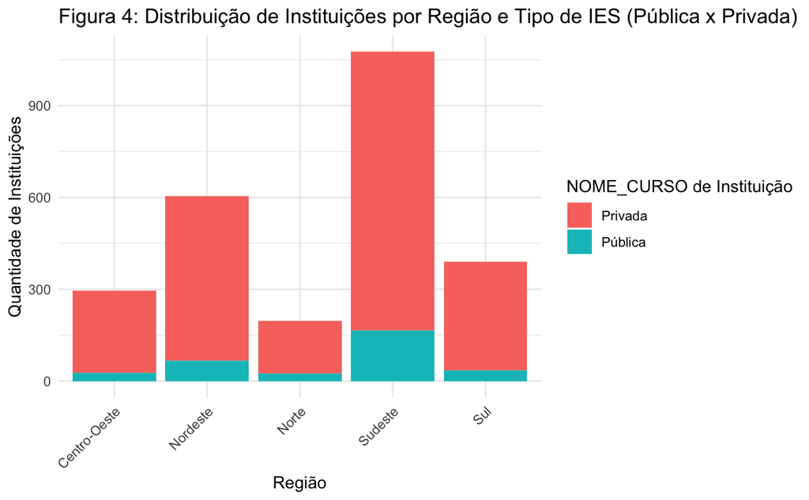

```r
library(dplyr)
library(ggplot2)


# 2. Criação do Gráfico de Barras Empilhadas
ggplot(dados_ies, aes(x = REGIAO, fill = REDE)) +
  # geom_bar() calcula a contagem (quantidade) automaticamente.
  # position = "stack" é o padrão, mas é explícito aqui.
  geom_bar(position = "stack") +

  labs(
    title = 'Figura 4: Distribuição de Instituições por Região e Tipo de IES (Pública x Privada)',
    x = 'Região',
    y = 'Quantidade de Instituições'
  ) +
  scale_fill_discrete(name = "NOME_CURSO de Instituição") + # Define o título da legenda
  theme_minimal() +
  theme(
    axis.text.x = element_text(angle = 45, hjust = 1) # Gira os rótulos do eixo X, se necessário
  )
```

## 3.3. Em relação aos Curso